# ETC5521 Tutorial 1

Introduction to exploratory data analysis

Author

Prof. Di Cook

## 🎯 Objectives

This is the first tutorial meeting of the semester. The goal is to get to know other people in the class with you, and your tutors, and check you’ve got the right skills to get started, and to begin thinking about exploratory data analysis.

## 1. How good are your detective skills?

Being good at noticing something unexpected or unusual is an important skills for exploratory data analysis. This exercise is designed to practice your detective skills.

Play the game `alzheimer_test` from the `fun` package by running this code:

```r
library(fun)
x = alzheimer_test()
```

You will be given 6 tasks to complete. Each one is to find a specific letter hidden among a $10\times 30$ grid of letters. Each time you will also be asked to enter the row, and then the column of your answer. You can take as much time to work these out as you need. When you are finished, answer these questions:

1. Which task did you THINK was the most difficult?
2. Your data was saved into the object `x`. Which task does the DATA say was most difficult based, based on the time taken to answer, which is variable `tm1.1.j.` in your results data?
3. Save the dataset to `alzheimers.rda` file, and share with your tutor.

**SolutionSolution**

```r
load(here::here("data/alzheimers.rda"))
library(dplyr)
x |>
  select(char1.1.j., char2.1.j., tm1.1.j.) |>
  arrange(desc(tm1.1.j.))
```

```
           char1.1.j. char2.1.j.  tm1.1.j.
ans.user.2          M          N 30.839718
ans.user.3          I          T 19.695932
ans.user.5          D          O 17.189302
ans.user.1          O          C 16.534676
ans.user.4          F          E  4.424869
ans.user            9          6  3.812386
```

## 2. Are you like everyone else?

With the combined data collated by the tutor, answer these questions:

1. What was the task that was the most difficult based on the overall average time?
2. Which task had the most variation among the class?
3. Is there a relationship between the location of the hidden letter and the time taken to find it? (How should you calculate this?)
4. How fast are you relative to your class mates? (How should you calculate this?)

**SolutionSolution**

The code to be able to answer the questions above is:

```r
load(here::here("data/alzheimers-class.rda"))
xclass |>
  group_by(char2.1.j.) |>
  summarise(m = mean(tm1.1.j.)) |>
  arrange(desc(m))
```

```
# A tibble: 6 × 2
  char2.1.j.     m
  <chr>      <dbl>
1 N          20.8
2 O          15.1
3 T           7.75
4 C           5.99
5 6           5.18
6 E           4.11
```

```r
xclass |>
  group_by(char2.1.j.) |>
  summarise(s = sd(tm1.1.j.)) |>
  arrange(desc(s))
```

```
# A tibble: 6 × 2
  char2.1.j.     s
  <chr>      <dbl>
1 N          17.0
2 O          13.0
3 T           7.11
4 C           6.01
5 6           3.09
6 E           2.35
```

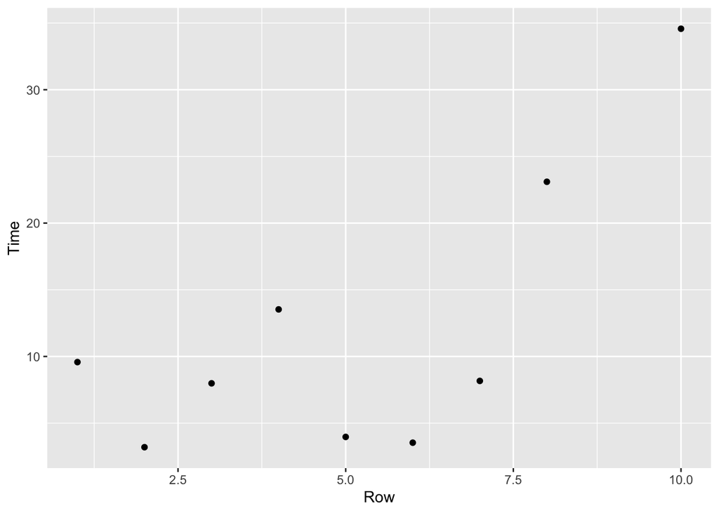

```r
library(ggplot2)
xclass |>
  group_by(X1.1) |>
  summarise(m = mean(tm1.1.j.)) |>
  ggplot(aes(X1.1, m)) +
    geom_point() +
    xlab("Row") +
    ylab("Time")
```

Should you adjust by the letter? Probably, because some letters might just be harder to find than others, regardless of where they are hidden. If certain letters happen to have been placed more often in particular rows, then those rows would look artificially slow or fast, when really it’s the letter that’s driving the difference. Adjusting for letter removes this confounding.

```r
tasks <- xclass |>
  group_by(char2.1.j.) |>
  summarise(m = mean(tm1.1.j.),
            s = sd(tm1.1.j.))
myresults <- xclass |>
  filter(id == 1) # Use your id here!
myresults |>
  left_join(tasks, by = "char2.1.j.") |>
  mutate(std_score = (tm1.1.j. - m)/s) |>
  select(char2.1.j., std_score)
```

```
  char2.1.j.  std_score
1          6 -0.4426827
2          C  1.7538244
3          N  0.5898853
4          T  1.6799758
5          E  0.1338864
6          O  0.1582762
```

## 3. Share your GitHub names with your tutor

Please provide your GitHub username to your tutor, using the Google sheet provided. See [this sheet](https://drive.google.com/drive/folders/1vnyfXcKccxoZBr68YLPEO5PDMuN8J1Sk?usp=sharing).

## 👌 Finishing up

Make sure you say thanks and good-bye to your tutor. This is a time to also report what you enjoyed and what you found difficult.